# EDA

## Variable Descriptions

Patient_ID Unique anonymized identifier per patient Visit_Number Sequential clinical visit index Visit_Timestamp Date of each visit Scan_Type Type of scan performed (Ultrasound, FNA, Elastography) Age, Gender, Height, Weight, BMI Basic demographics and body metrics Family_History Binary indicator for thyroid disease in family history Smoking_Status Categorical: Smoker, Non-Smoker, Former Smoker Radiation_Exposure Prior exposure to radiation therapy or sources Nodule_Size_mm, Margin_Sharpness, Shape_Score, Echogenicity_Index Radiomic features from scans

Calcification_Presence, Capsular_Invasion_Indicator Structural indicators linked to malignancy

Vascularity_Score, Texture_Entropy, Asymmetry_Score Advanced scan-derived imaging biomarkers

TSH_Risk_Level, TPOAb_Probability, Thyroglobulin_Level_Predicted, Calcitonin_Level_Predicted, Reverse_T3_Index Hormonal indicators Heart_Rate, Daily_Steps, Sleep_Patterns, Body_Temperature, Pulse_Oximetry Smart device vitals

Stress_Level, Symptom_Onset_Duration, Hormonal_Change_Rate, Medication_Adherence Behavioral and progression indicators

Diagnosis_Label Binary classification (0: Benign, 1: Malignant) Cancer_Type Categorical subtype (e.g., Papillary, Follicular, Medullary, etc.)

Recurrence_Risk Binary risk estimation for recurrence likelihood

```r
library(readr)
library(ggplot2)
library(purrr)
library(tidyverse)
library(cowplot)
library(MASS)
library(lavaan)

thyro <- read_csv("~/Desktop/UM/BIOSTAT625/Project//ThyroTrack-MV Processed Dataset.csv", show_col_types = F)
```

```r
patient_freq =
  thyro %>%
  group_by(Patient_ID) %>%
  summarize(n = n())

patient_freq4 = patient_freq %>%
  filter(n >= 4)

patient_freq4 = patient_freq4$Patient_ID

thyro4 =
  thyro %>%
  filter(Patient_ID %in% patient_freq4) %>%
  group_by(Patient_ID) %>%
  mutate(
    across(c(4, 6, 10, 11, 12, 17, 21, 22, 35, 36, 37, 38) - 1, as.factor)
  )  %>%
  mutate(
    elapsed_time_days = as.numeric((Visit_Timestamp - min(Visit_Timestamp)))
  ) %>%
  ungroup() %>%
  group_by(Patient_ID) %>%
  mutate(
    elapsed_time_prop = elapsed_time_days / max(elapsed_time_days)
  ) %>%
  ungroup()


ranking = thyro4 %>%
  group_by(Patient_ID) %>%
  summarize(
    ave_visitFreq = max(elapsed_time_days) / max(Visit_Number)
  ) %>%
  mutate(rank_visitFreq = as.factor(ntile(ave_visitFreq, 4))) %>%
  ungroup() %>%
  mutate(ID = as.numeric(factor(Patient_ID)))



thyro4 = thyro4 %>%
  left_join(., y = ranking, by = "Patient_ID", keep = F) %>%
  dplyr::select(-c(ave_visitFreq))
```

```r
L1 = list(
thyro4 %>%
  ggplot(aes(
    x = Thyroglobulin_Level_Predicted,
  )) +
  geom_density(alpha = 0.50,
               fill = "purple3",
               adjust = 2) +
  xlab("Tg not transformed")
,
thyro4 %>%
  ggplot(aes(
    x = Calcitonin_Level_Predicted
  )) +
  geom_density(alpha = 0.50,
               fill = "purple3",
               adjust = 2) +
  xlab("Ct not transformed")
,
thyro4 %>%
  ggplot(aes(
    x = Reverse_T3_Index
  )) +
  geom_density(alpha = 0.50,
               fill = "purple3",
               adjust = 2) +
  xlab("rT3 as is")
)
```

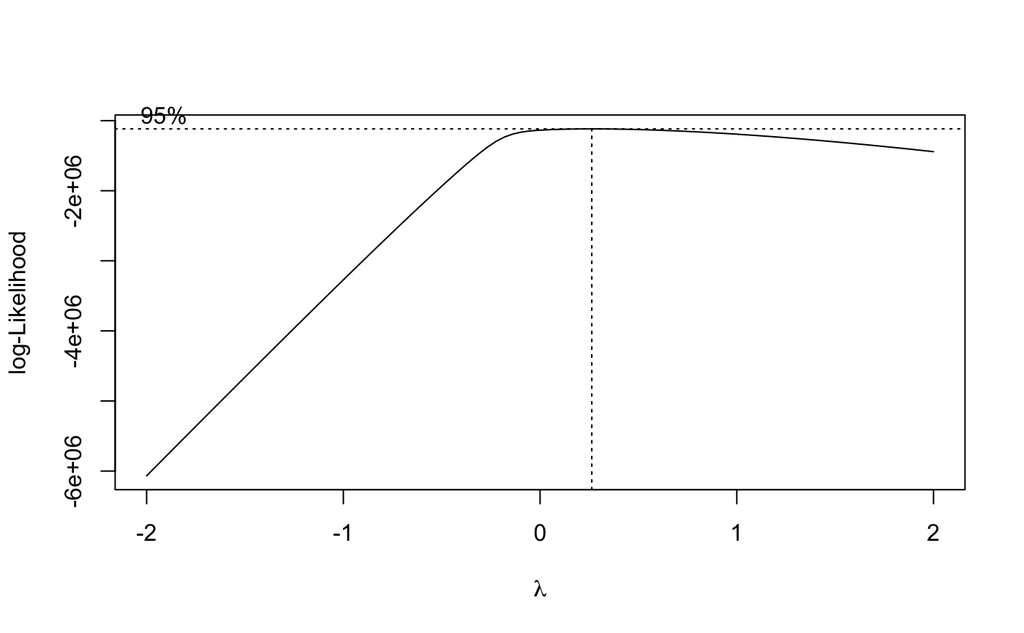

```r
m1 <- lm(Thyroglobulin_Level_Predicted + 1e-6 ~ 1, data = thyro4)
bc1 = MASS::boxcox(m1, plotit = TRUE)
```

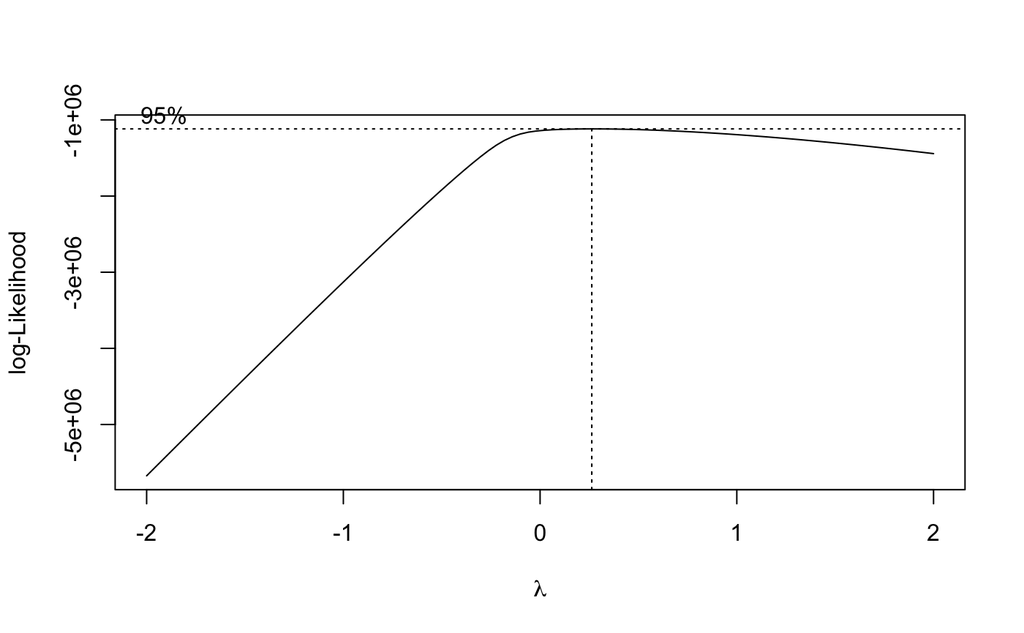

```r
optLamda_tg = bc1$x[which.max(bc1$y)]


m2 <- lm(Calcitonin_Level_Predicted + 1e-6 ~ 1, data = thyro4)
bc2 = MASS::boxcox(m2, plotit = TRUE)
```

```r
optLambda_calc = bc2$x[which.max(bc2$y)]

thyro4 = thyro4 %>%
  mutate(
    `TgT` =
      ((Thyroglobulin_Level_Predicted + 1e-6)^0.25 - 1) / 0.25,
    `CtT` = ((Calcitonin_Level_Predicted + 1e-6)^0.25 -1) / 0.25,
    rT3 = Reverse_T3_Index
  )

rm(optLambda_calc, optLamda_tg, bc1, bc2, m1, m2)
```

#### Exploratory Data Analysis

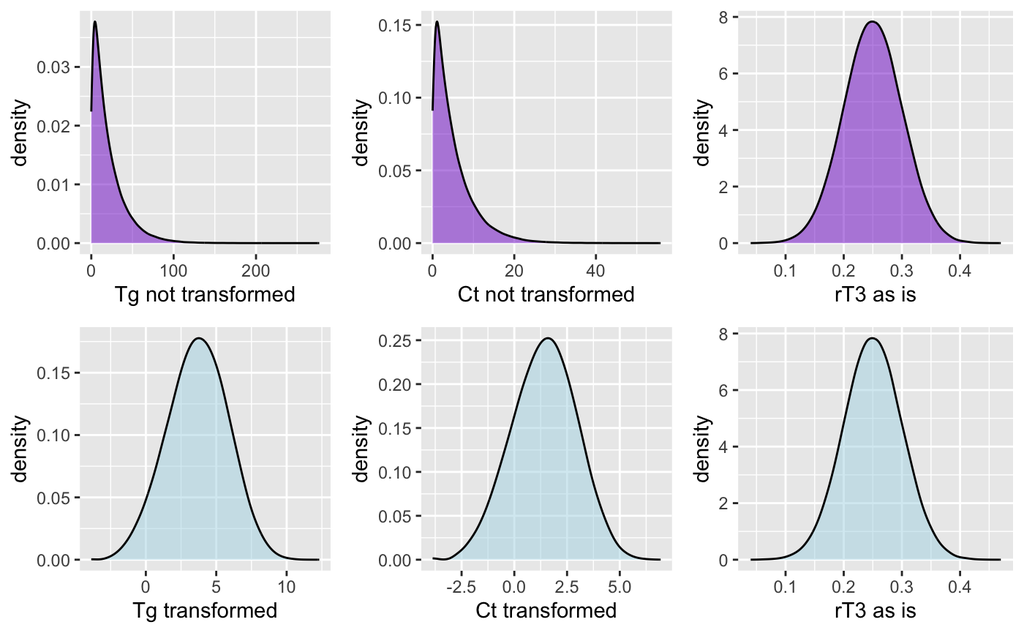

```r
L2 =
list(thyro4 %>%
  ggplot(aes(
    x = TgT,
  )) +
  geom_density(alpha = 0.50,
               fill = "lightblue",
               adjust = 2)+
    xlab("Tg transformed")
,
thyro4 %>%
  ggplot(aes(
    x = CtT
  )) +
  geom_density(alpha = 0.50,
               fill = "lightblue",
               adjust = 2)+
  xlab("Ct transformed")
,
thyro4 %>%
  ggplot(aes(
    x = rT3
  )) +
  geom_density(alpha = 0.50,
               fill = "lightblue",
               adjust = 2) +
  xlab("rT3 as is")
)

plot_grid(plotlist = c(L1, L2))
```

```r
list(
  cor(thyro4$rT3, thyro4$CtT),
  cor(thyro4$rT3, thyro4$TgT),
  cor(thyro4$TgT, thyro4$CtT)
)
```

```
[[1]]
[1] -0.001178221

[[2]]
[1] 0.000561061

[[3]]
[1] 0.00102506
```

Completely uncorrelated!

#### Explore the relationship between predictors and responses. Picking covariates of interest based on backward selection.

```r
summary(mlr_tgStep)
```

```
Call:
lm(formula = TgT ~ Visit_Number + Daily_Steps + Sleep_Patterns +
    elapsed_time_prop + Body_Temperature, data = data_tg)

Residuals:
    Min      1Q  Median      3Q     Max
-7.5830 -1.4674  0.0392  1.5137  8.6588

Coefficients:
                    Estimate Std. Error t value Pr(>|t|)
(Intercept)        2.783e+00  6.204e-01   4.486 7.27e-06 ***
Visit_Number       1.255e-02  8.387e-03   1.496   0.1346
Daily_Steps        3.042e-06  1.852e-06   1.643   0.1004
Sleep_Patterns    -5.527e-03  2.933e-03  -1.884   0.0596 .
elapsed_time_prop -5.256e-02  2.780e-02  -1.891   0.0587 .
Body_Temperature   2.465e-02  1.694e-02   1.455   0.1456
---
Signif. codes:  0 ‘***’ 0.001 ‘**’ 0.01 ‘*’ 0.05 ‘.’ 0.1 ‘ ’ 1

Residual standard error: 2.155 on 179905 degrees of freedom
Multiple R-squared:  6.733e-05, Adjusted R-squared:  3.954e-05
F-statistic: 2.423 on 5 and 179905 DF,  p-value: 0.03326
```

```r
data_ct = thyro4 %>% dplyr::select(-c(Patient_ID, Calcitonin_Level_Predicted))
mlr_ct = lm(formula = CtT ~ ., data = data_ct)

summary(mlr_ct)

step(mlr_ct, direction = "backward", trace = 0) # A very time-consuming command.
# Disabled output, so it's running in background. Final call is below.

mlr_ctStep = lm(formula = CtT ~ Visit_Number + Visit_Timestamp + Scan_Type +
    Vascularity_Score + Capsular_Invasion_Indicator + TSH_Risk_Level,
    data = data_ct)

summary(mlr_ctStep)
```

[output not shown]

```r
data_rt3 = thyro4 %>% dplyr::select(-c(Patient_ID, Reverse_T3_Index))
mlr_rT3 = lm(formula = rT3 ~ ., data = data_rt3)

summary(mlr_rT3)

# step(mlr_rT3, direction = "backward", trace = 0) # A very time-consuming command.
## Disabled output, so it's running in background. Final call is the output

mlr_rT3Step = lm(formula = rT3 ~ Scan_Type + Weight_kg + Family_History + Smoking_Status +
    Nodule_Size_mm + Vascularity_Score + Texture_Entropy + TPOAb_Probability +
    Symptom_Onset_Duration + Hormonal_Change_Rate + Medication_Adherence,
    data = data_rt3)

summary(mlr_rT3Step)
```

[output not shown]

```r
d1 = thyro4 %>%
  group_by(
    Visit_Number,
    TSH_Risk_Level,
    Calcification_Presence,
    Gender,
    factor(Age > 50),
    Cancer_Type
    ) %>%
  summarise(
    medianPropTime = median(elapsed_time_prop),
    q1PropTime = quantile(elapsed_time_prop, 0.25),
    q3PropTime = quantile(elapsed_time_prop, 0.75),
    medianTg = median(TgT),
    q1Tg = quantile(TgT, 0.25),
    q3Tg = quantile(TgT, 0.75),
    medianCt = median(CtT),
    q1CtT = quantile(CtT, 0.25),
    q3CtT = quantile(CtT, 0.75),
    medianrT3 = median(rT3),
    q1rT3 = quantile(rT3, 0.25),
    q3rT3 = quantile(rT3, 0.75)
  ) %>%
  as.data.frame()

d1.1 = d1 %>%
  group_by(Visit_Number) %>%
  summarize(medPT =  median(medianPropTime),
            medTgT =  median(medianTg),
            medCt = median(medianCt),
            medrT3 = median(medianrT3))

d1.2 = d1 %>%
  group_by(Visit_Number, `factor(Age > 50)`) %>%
  summarize(medPT =  median(medianPropTime),
            medTgT =  median(medianTg),
            medCt = median(medianCt),
            medrT3 = median(medianrT3))

d1.3 = d1 %>%
  group_by(Visit_Number, Gender) %>%
  summarize(medPT =  median(medianPropTime),
            medTgT =  median(medianTg),
            medCt = median(medianCt),
            medrT3 = median(medianrT3))

d1.4 = d1 %>%
  group_by(Visit_Number, TSH_Risk_Level) %>%
  summarize(medPT =  median(medianPropTime),
            medTgT =  median(medianTg),
            medCt = median(medianCt),
            medrT3 = median(medianrT3))

d1.5 = d1 %>%
  group_by(Visit_Number, Calcification_Presence) %>%
  summarize(medPT =  median(medianPropTime),
            medTgT =  median(medianTg),
            medCt = median(medianCt),
            medrT3 = median(medianrT3))

d1.6 = d1 %>%
  group_by(Visit_Number, Cancer_Type) %>%
  summarize(medPT =  median(medianPropTime),
            medTgT =  median(medianTg),
            medCt = median(medianCt),
            medrT3 = median(medianrT3))
```

```r
p1 = list(
d1 %>%
  ggplot(aes(x = medianPropTime, y = medianTg)) +
  geom_point() +
  geom_line(data = d1.1, aes(x = medPT, y = medTgT), linewidth = 1, alpha = 0.3) +
  geom_line(data = d1.2, aes(x = medPT, y = medTgT, group = `factor(Age > 50)`,
                             color = `factor(Age > 50)`))
,
d1 %>%
  ggplot(aes(x = medianPropTime, y = medianTg)) +
  geom_point() +
  geom_line(data = d1.1, aes(x = medPT, y = medTgT), linewidth = 1, alpha = 0.3) +
  geom_line(data = d1.3, aes(x = medPT, y = medTgT, group = Gender,
                             color = Gender))
,
d1 %>%
  ggplot(aes(x = medianPropTime, y = medianTg)) +
  geom_point() +
  geom_line(data = d1.1, aes(x = medPT, y = medTgT), linewidth = 1, alpha = 0.3) +
  geom_line(data = d1.4, aes(x = medPT, y = medTgT, group = TSH_Risk_Level,
                             color = TSH_Risk_Level))
,
d1 %>%
  ggplot(aes(x = medianPropTime, y = medianTg)) +
  geom_point() +
  geom_line(data = d1.1, aes(x = medPT, y = medTgT), linewidth = 1, alpha = 0.3) +
  geom_line(data = d1.5, aes(x = medPT, y = medTgT, group = Calcification_Presence,
                             color = Calcification_Presence))
,
d1 %>%
  ggplot(aes(x = medianPropTime, y = medianTg)) +
  geom_point() +
  geom_line(data = d1.1, aes(x = medPT, y = medTgT), linewidth = 1, alpha = 0.3) +
  geom_line(data = d1.6, aes(x = medPT, y = medTgT, group = Cancer_Type,
                             color = Cancer_Type))
)
```

```r
p2 = list(
d1 %>%
  ggplot(aes(x = medianPropTime, y = medianCt)) +
  geom_point() +
  geom_line(data = d1.1, aes(x = medPT, y = medCt), linewidth = 1, alpha = 0.3) +
  geom_line(data = d1.2, aes(x = medPT, y = medCt, group = `factor(Age > 50)`,
                             color = `factor(Age > 50)`))
,
d1 %>%
  ggplot(aes(x = medianPropTime, y = medianCt)) +
  geom_point() +
  geom_line(data = d1.1, aes(x = medPT, y = medCt), linewidth = 1, alpha = 0.3) +
  geom_line(data = d1.3, aes(x = medPT, y = medCt, group = Gender,
                             color = Gender))
,
d1 %>%
  ggplot(aes(x = medianPropTime, y = medianCt)) +
  geom_point() +
  geom_line(data = d1.1, aes(x = medPT, y = medCt), linewidth = 1, alpha = 0.3) +
  geom_line(data = d1.4, aes(x = medPT, y = medCt, group = TSH_Risk_Level,
                             color = TSH_Risk_Level))
,
d1 %>%
  ggplot(aes(x = medianPropTime, y = medianCt)) +
  geom_point() +
  geom_line(data = d1.1, aes(x = medPT, y = medCt), linewidth = 1, alpha = 0.3) +
  geom_line(data = d1.5, aes(x = medPT, y = medCt, group = Calcification_Presence,
                             color = Calcification_Presence))
,
d1 %>%
  ggplot(aes(x = medianPropTime, y = medianCt)) +
  geom_point() +
  geom_line(data = d1.1, aes(x = medPT, y = medCt), linewidth = 1, alpha = 0.3) +
  geom_line(data = d1.6, aes(x = medPT, y = medCt, group = Cancer_Type,
                             color = Cancer_Type))
)
```

```r
p3 = list(
d1 %>%
  ggplot(aes(x = medianPropTime, y = medianrT3)) +
  geom_point() +
  geom_line(data = d1.1, aes(x = medPT, y = medrT3), linewidth = 1, alpha = 0.3) +
  geom_line(data = d1.2, aes(x = medPT, y = medrT3, group = `factor(Age > 50)`,
                             color = `factor(Age > 50)`))
,
d1 %>%
  ggplot(aes(x = medianPropTime, y = medianrT3)) +
  geom_point() +
  geom_line(data = d1.1, aes(x = medPT, y = medrT3), linewidth = 1, alpha = 0.3) +
  geom_line(data = d1.3, aes(x = medPT, y = medrT3, group = Gender,
                             color = Gender))
,
d1 %>%
  ggplot(aes(x = medianPropTime, y = medianrT3)) +
  geom_point() +
  geom_line(data = d1.1, aes(x = medPT, y = medrT3), linewidth = 1, alpha = 0.3) +
  geom_line(data = d1.4, aes(x = medPT, y = medrT3, group = TSH_Risk_Level,
                             color = TSH_Risk_Level))
,
d1 %>%
  ggplot(aes(x = medianPropTime, y = medianrT3)) +
  geom_point() +
  geom_line(data = d1.1, aes(x = medPT, y = medrT3), linewidth = 1, alpha = 0.3) +
  geom_line(data = d1.5, aes(x = medPT, y = medrT3, group = Calcification_Presence,
                             color = Calcification_Presence))
,
d1 %>%
  ggplot(aes(x = medianPropTime, y = medianrT3)) +
  geom_point() +
  geom_line(data = d1.1, aes(x = medPT, y = medrT3), linewidth = 1, alpha = 0.3) +
  geom_line(data = d1.6, aes(x = medPT, y = medrT3, group = Cancer_Type,
                             color = Cancer_Type))
)
```

Saving dataset.

```r
write.csv(thyro4, file = "thyro4.csv", row.names = FALSE)
```